# IncomeGroupClassification_CaseStudy_DSBA_V2_Suresh_Pawar

#### salary vs occupation

```
salary              <=50K   >50K    All
occupation
All                 24692   7839  32531
Exec-managerial      2097   1968   4065
Prof-specialty       2278   1858   4136
Sales                2666    983   3649
Craft-repair         3164    929   4093
Adm-clerical         3259    507   3766
Transport-moving     1277    320   1597
Tech-support          644    283    927
Machine-op-inspct    1750    249   1999
Protective-serv       438    211    649
Unknown              1652    191   1843
Other-service        3153    137   3290
Farming-fishing       877    115    992
Handlers-cleaners    1283     86   1369
Armed-Forces            8      1      9
Priv-house-serv       146      1    147
------------------------------------------------------------------------------------------------------------------------
```

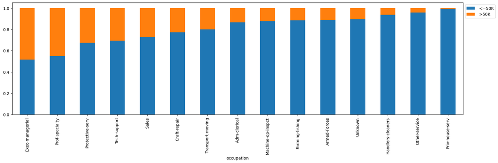

```python
stacked_barplot(df, "occupation", "salary")
```

- ~50% of the people whose occupation is of Executive Manager, Professor-speciality have a salary above $50,000
- People with occupations like Private house service,handlers-cleaners, farming-fishing have a higher likelihood of having below 50K salary.

#### salary vs race

```
salary               <=50K   >50K    All
race
All                  24692   7839  32531
White                20674   7115  27789
Black                 2735    387   3122
Asian-Pac-Islander     762    276   1038
Amer-Indian-Eskimo     275     36    311
Other                  246     25    271
------------------------------------------------------------------------------------------------------------------------
```

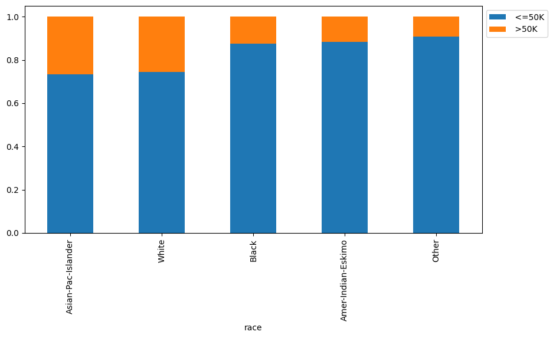

```python
stacked_barplot(df, "race", "salary")
```

- 25% of the White and Asia-Pacific people have a salary more than 50K salary as compared to people from other race.

#### salary vs workclass

```
salary             <=50K   >50K    All
workclass
All                24692   7839  32531
Private            17706   4961  22667
Self-emp-not-inc    1816    724   2540
Self-emp-inc         494    622   1116
Local-gov           1476    617   2093
Federal-gov          589    371    960
State-gov            945    353   1298
Unknown             1645    191   1836
Never-worked           7      0      7
Without-pay           14      0     14
------------------------------------------------------------------------------------------------------------------------
```

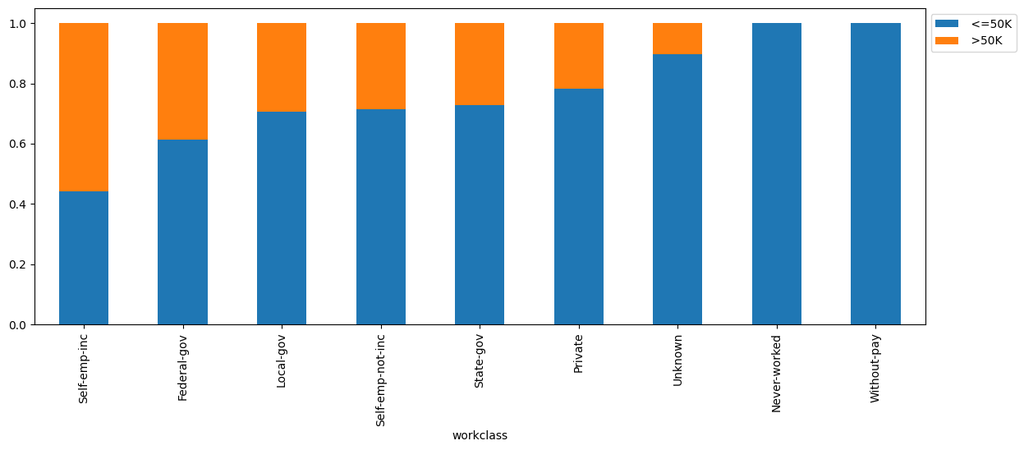

```python
stacked_barplot(df, "workclass", "salary")
```

- ~50% of the self-employed people have a salary above 50K followed by ~40% of the federal govt employee who has salary more than 50K.
- ~20% of the people working in the private sector earn more than 50K.

#### salary vs marital_status

```
salary           <=50K   >50K    All
marital_status
All              24692   7839  32531
married           8293   6700  14993
not_married       6229    648   6877
Never-married    10170    491  10661
------------------------------------------------------------------------------------------------------------------------
```

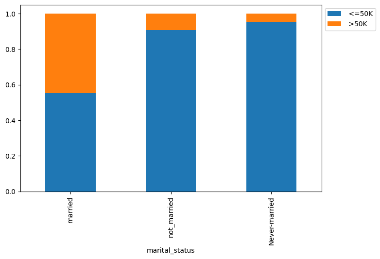

```python
stacked_barplot(df, "marital_status", "salary")
```

- Married people have a higher likelihood of getting a salary above 50K compared to Never Married and Not married people.

#### salary vs age

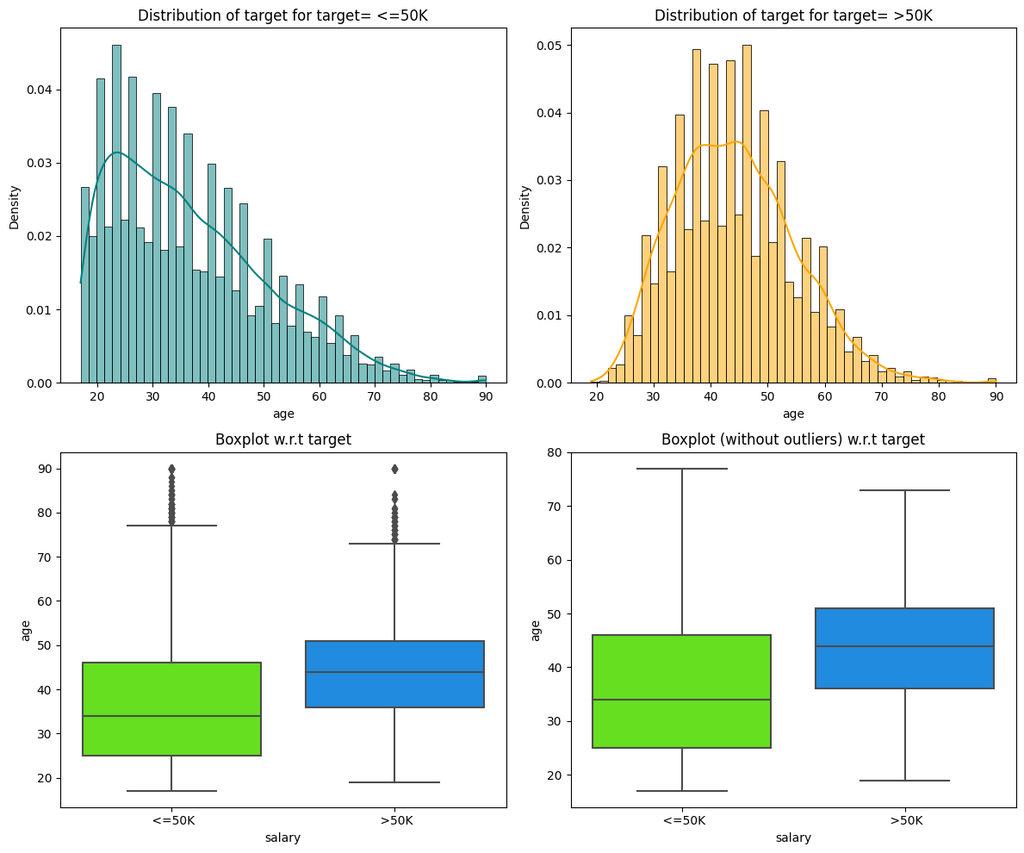

```python
distribution_plot_wrt_target(df, "age", "salary")
```

#### salary vs working_hours_per_week

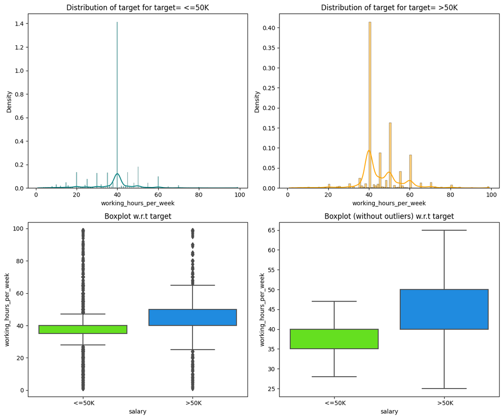

```python
distribution_plot_wrt_target(df, "working_hours_per_week", "salary")
```

- Majority of people having above 50K salary work around 40 hours per week.
- Those having >50K salary have a higher range of working hours as compared to the ones with <=50K, but there are outliers present.

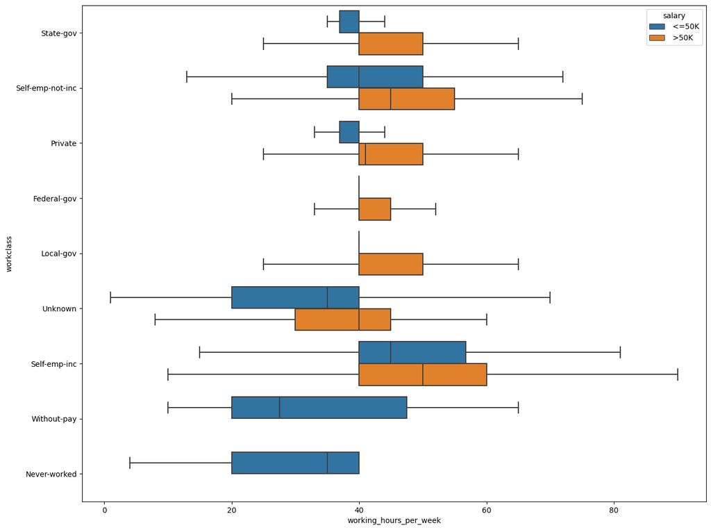

```python
# lets see how working hours per week vary across different occupation
plt.figure(figsize=(15, 12))
sns.boxplot(
    y="workclass", x="working_hours_per_week", data=df, hue="salary", showfliers=False
)
plt.show()
```

- Private sector employees work for more hours to get a salary above 50K.
- There's large variability in the working hours of self-employed people which makes sense as they might be working at their ease.
- Without pay and never worked will have no income or less than 50K income.
- The number of working hours for many government employees is concentrated at 40 hrs a week, which makes sense as government employees generally have fixed working hours.

### To jump back to the EDA summary section, click here.